# The Effect of Vitamin C on Tooth Growth in Guinea Pigs

Statistical Inference Course Project 2

Xinchun Tian

# Exploratory Data Analysis

Using some simple $R$ tools to do some initial exploratory data anlysis. 1. Show part of the data in a table (measurements 25-35)

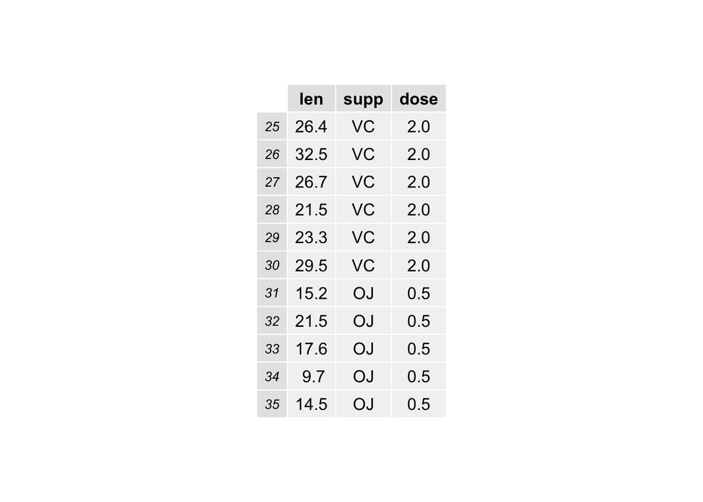

2. Show the summary of the data using *summary*

```
##       len        supp         dose
##  Min.   : 4.20   OJ:30   Min.   :0.500
##  1st Qu.:13.07   VC:30   1st Qu.:0.500
##  Median :19.25           Median :1.000
##  Mean   :18.81           Mean   :1.167
##  3rd Qu.:25.27           3rd Qu.:2.000
##  Max.   :33.90           Max.   :2.000
```

3. Show the summary of the data using *str*

```
## 'data.frame':    60 obs. of  3 variables:
##  $ len : num  4.2 11.5 7.3 5.8 6.4 10 11.2 11.2 5.2 7 ...
##  $ supp: Factor w/ 2 levels "OJ","VC": 2 2 2 2 2 2 2 2 2 2 ...
##  $ dose: num  0.5 0.5 0.5 0.5 0.5 0.5 0.5 0.5 0.5 0.5 ...
```

4. Plot the data

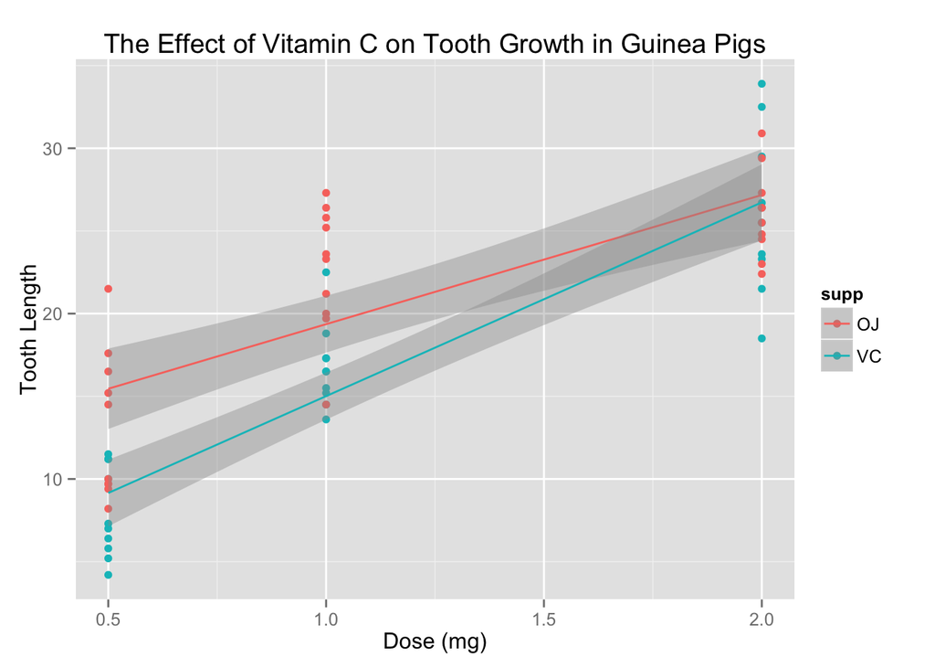

From the above exploratory data analysis, we can have obtain the following observations about the ToothGrowth dataset.  
1. There are 60 observations, 3 variables,  
2. Two factors: VC and OJ.  
According to the help page of $R$, the summary of the ToothGrowth dataset can be “*The response is the length of odontoblasts (teeth) in each of 10 guinea pigs at each of three dose levels of Vitamin C (0.5, 1, and 2 mg) with each of two delivery methods (orange juice or ascorbic acid).*”

# Two-group Confidence Intervals and Hypothesis Tests

## Compare VC vs OJ effects at different dose levels

```
## [1] "The variance of VC 7.544 is different from the variance of OJ 19.889, therefore the T-test will use the option of va.equal=FALSE"
```

2. dose is 1.0 mg

```
## [1] "The variance of VC 6.327 is different from the variance of OJ 15.296, therefore the T-test will use the option of va.equal=FALSE"
```

```
##          [,1]     [,2]
## [1,] 2.802148 9.057852
```

The 95% confidence interval is [2.802, 9.058], which means “OJ” is more effective than “VC” on length of odontoblasts.

3. dose is 2.0 mg

```
## [1] "The variance of VC 23.018 is different from the variance of OJ 7.049, therefore the T-test will use the option of va.equal=FALSE"
```

```
##          [,1]    [,2]
## [1,] -3.79807 3.63807
```

The 95% confidence interval is [-3.798, 3.638], which means “OJ” is not different from “VC” on length of odontoblasts.

## Compare dose effects (0.5 and 2.0 mg) at VC or OJ

There are three dose levels (0.5, 1.0 and 2.0 mg).  
1. supp is VC

```
## [1] "The variance of 0.5 mg dose 7.544 is different from the variance of 2.0 mg dose 23.018, therefore the T-test will use the option of va.equal=FALSE"
```

2. supp is OJ

```
## [1] "The variance of 0.5 mg dose 19.889 is different from the variance of 2.0 mg dose 7.049, therefore the T-test will use the option of va.equal=FALSE"
```